# Chapter 2: Describing Distributions with Numbers

The Practice of Statistics in the Life Sciences by Brigitte Baldi and David S. Moore

Instructor: Ali Raisolsadat

Part I: Exploring Data (The Basics)

# 2 Chapter 2: Describing Distributions with Numbers

## 2.1 Describing Distributions with Numbers

Chapter 1 established an important rule for data analysis: **plot the data before relying on numerical summaries**. Histograms, dotplots and other displays allow us to see shape, unusual observations, centre and spread.

### 2.1.1 The Limits of Human Perception

Graphs are powerful, but visual judgments are not perfectly objective. Two people can look at the same skewed histogram and give slightly different estimates of its centre or spread. Scientific conclusions should therefore not depend only on where a person thinks the “middle” appears to be.

Chapter 2 translates the visual ideas from **SOCS** into numerical summaries that can be calculated and reproduced.

- **Shape** is still assessed primarily from a graph.
- **Outliers** can be investigated visually and later flagged using a numerical rule.
- **Centre** can be summarized using the mean or median.
- **Spread** can be summarized using the standard deviation or interquartile range.

Numerical summaries provide a second description of the same distribution. They do not replace the graph; they complement it.

This chapter develops two main pairs of summaries. The **mean and standard deviation** are commonly used for reasonably symmetric distributions without strong outliers. The **median and interquartile range (IQR)** are resistant summaries and are often preferred for strongly skewed distributions or distributions containing extreme observations.

> **A useful workflow**

> Plot the distribution first. Then choose numerical summaries that match the shape and unusual features visible in the graph.

### 2.1.2 From a Graph to Numerical Summaries

A measure of **centre** describes where a distribution is located or what value might be considered typical. A measure of **spread** describes how much the observations vary around that centre.

The choice of numerical summary should not be made before the distribution is examined. The mean can be strongly influenced by an extreme observation, while the median is much more resistant. A similar contrast exists between the standard deviation and the IQR.

## 2.2 Measuring Centre: Mean and Median

A researcher who asks for a typical pine needle length, a typical metabolic rate or a typical viral load is asking about the centre of a distribution. Two common measures of centre are the mean and the median.

### 2.2.1 The Mean ($\bar{x}$)

The **sample mean** is the ordinary arithmetic average. Every observation contributes its numerical value to the calculation.

If the observations are $x_1,x_2,\ldots,x_n$, then

$$\bar{x}
=
\frac{x_1+x_2+\cdots+x_n}{n}$$

Summation notation provides a shorter form.

$$\bar{x}
=
\frac{1}{n}\sum_{i=1}^{n}x_i$$

The symbol $\bar{x}$ is pronounced **x-bar**. It represents the mean of a sample. Later in the course, the Greek letter $\mu$ (mu) will be used for a population mean.

The subscript in $x_i$ simply labels an observation. For example, $x_1$ is the first listed observation and $x_{15}$ is the fifteenth. The subscript does **not** necessarily represent time or a ranking unless the context says that it does.

#### 2.2.1.1 Example 2.3: Mean of Pine Needle Lengths

**Question**

A sample contains 15 Aleppo pine needles with the following lengths in centimetres. What is the sample mean length?

| Observation | Length (cm) | Observation | Length (cm) | Observation | Length (cm) |
| --- | --- | --- | --- | --- | --- |
| 1 | 7.2 | 6 | 9.0 | 11 | 10.2 |
| 2 | 7.6 | 7 | 9.0 | 12 | 10.9 |
| 3 | 8.5 | 8 | 9.3 | 13 | 11.3 |
| 4 | 8.5 | 9 | 9.4 | 14 | 12.1 |
| 5 | 8.7 | 10 | 9.4 | 15 | 12.8 |

**Explanation**

The mean uses all 15 measurements. The observations are added, then the total is divided by the sample size.

The total length is

$$\sum_{i=1}^{15}x_i
=
143.9\text{ cm}$$

**Solution**

$$\bar{x}
=
\frac{143.9}{15}
\approx
9.59\text{ cm}$$

The mean needle length is approximately 9.59 cm.

The calculation can also be performed in R.

```r
# The vector contains the 15 observed pine needle lengths in centimetres.
aleppo_needles <- c(
  7.2, 7.6, 8.5, 8.5, 8.7,
  9.0, 9.0, 9.3, 9.4, 9.4,
  10.2, 10.9, 11.3, 12.1, 12.8
)

# mean() calculates the arithmetic average.
mean(aleppo_needles)
```

```
## [1] 9.593333
```

The formula and the R calculation emphasize an important property: the mean uses the numerical value of every observation.

### 2.2.2 The Median ($M$)

The **median** is the middle of the ordered data. It separates the observations into a lower part and an upper part.

For an odd number of observations, the median is the single middle observation after the data are sorted. Its position is

$$\frac{n+1}{2}$$

For an even number of observations, there are two middle observations. The median is the average of the values in positions $n/2$ and $n/2+1$.

The median is also the 50th percentile. With repeated values, it is more precise to say that at least half of the observations are no larger than the median and at least half are no smaller than the median.

### 2.2.3 Software Note: The Median in R

In R, the median is calculated with `median(x)`. When calculating a median by hand, we must sort the observations and locate the middle position ourselves. R performs the sorting internally and, when $n$ is even, automatically averages the two middle values.

#### 2.2.3.1 Example 2.1: Aleppo Pine Needles with Odd $n$

**Question**

What is the median of the 15 Aleppo pine needle lengths?

**Explanation**

The data are already sorted. Because $n=15$ is odd, the median occurs at position

$$\frac{15+1}{2}
=
8$$

The eighth observation is 9.3 cm.

**Solution**

$$M
=
9.3\text{ cm}$$

The same result can be obtained in R.

```r
# median() returns the middle value of the ordered data.
median(aleppo_needles)
```

```
## [1] 9.3
```

#### 2.2.3.2 Example 2.2: Torrey Pine Needles with Even $n$

**Question**

A sample contains 18 Torrey pine needle lengths.

21.2, 21.6, 21.7, 23.1, 23.7, 24.2, 24.2, 25.5, 26.6, 26.8, 28.9, 29.0, 29.7, 29.7, 30.2, 32.5, 33.7, 33.7

What is the median length?

**Explanation**

Because $n=18$ is even, the middle observations are the ninth and tenth values.

$$x_{(9)}
=
26.6$$

$$x_{(10)}
=
26.8$$

The median is their average.

**Solution**

$$M
=
\frac{26.6+26.8}{2}
=
26.7\text{ cm}$$

```r
# The vector contains the 18 Torrey pine needle lengths.
torrey_needles <- c(
  21.2, 21.6, 21.7, 23.1, 23.7, 24.2,
  24.2, 25.5, 26.6, 26.8, 28.9, 29.0,
  29.7, 29.7, 30.2, 32.5, 33.7, 33.7
)

# median() automatically handles an even sample size.
median(torrey_needles)
```

```
## [1] 26.7
```

The mean and median can be close when a distribution is roughly symmetric. Their behaviour can be very different when the data contain an extreme observation.

## 2.3 Comparing the Mean and Median: Resistance

A numerical summary is called **resistant** when a small number of extreme observations do not change it very much.

The median is resistant because it depends mainly on the order of the observations. The mean is non-resistant because every observed value enters directly into its calculation.

### 2.3.1 An Extreme Recovery Time

**Question**

Suppose patients record the number of days required for heart-rate variability (HRV) to return to baseline after an illness. Consider the following two samples.

Original sample:

4, 6, 7, 8, 9

Sample containing one unusually long recovery time:

4, 6, 7, 8, 45

How do the mean and median change?

**Explanation**

The central four values remain almost unchanged. Only the largest value changes substantially.

For the original sample,

$$\bar{x}
=
6.8$$

$$M
=
7$$

For the sample containing 45,

$$\bar{x}
=
14$$

$$M
=
7$$

**Solution**

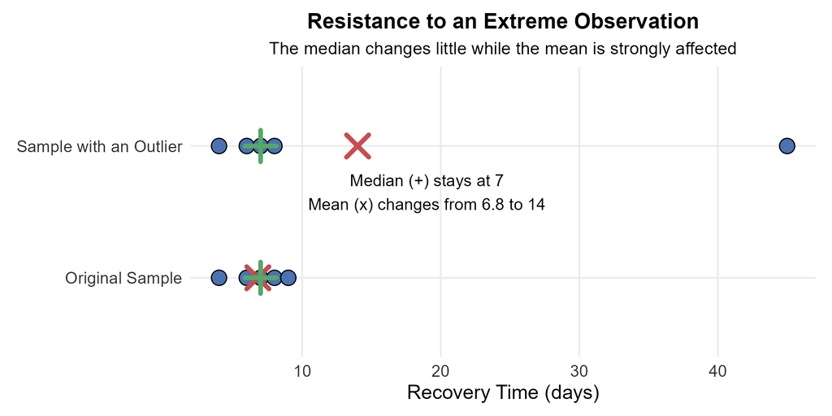

The median remains at 7 days, while the mean changes from 6.8 days to 14 days. The median is therefore much more resistant to this extreme value.

| Statistic | Original sample | Sample with 45 days |
| --- | --- | --- |
| Median | 7 days | 7 days |
| Mean | 6.8 days | 14 days |

### 2.3.2 Shape and the Choice of Centre

The resistance of the median explains why the shape of a distribution matters when choosing a measure of centre.

A long right tail contains unusually large observations. These values tend to pull the mean upward. A long left tail contains unusually small observations, which tend to pull the mean downward.

| Distribution shape | Typical relationship |
| --- | --- |
| Roughly symmetric | Mean $\approx$ median |
| Skewed right | Mean is often greater than the median |
| Skewed left | Mean is often less than the median |

These relationships are useful patterns, not universal mathematical rules for every possible dataset. The graph should always be examined.

#### 2.3.2.1 Illustrative Example: Viral Load and Skewness

**Question**

A laboratory records the following illustrative viral-load measurements in copies per mL for 20 patients.

| 120 | 140 | 160 | 180 | 200 |
| --- | --- | --- | --- | --- |
| 220 | 250 | 270 | 300 | 330 |
| 360 | 400 | 450 | 520 | 600 |
| 750 | 900 | 1300 | 2500 | 6000 |

What are the mean and median? Which measure better represents a typical value for this strongly right-skewed dataset?

**Explanation**

Most observations are below 1000 copies/mL, while a small number of observations are much larger. The values 2500 and 6000 create a long right tail.

The median depends on the middle observations.

$$M
=
345$$

The mean uses every value.

$$\bar{x}
=
797.5$$

The large observations in the right tail increase the mean substantially.

**Solution**

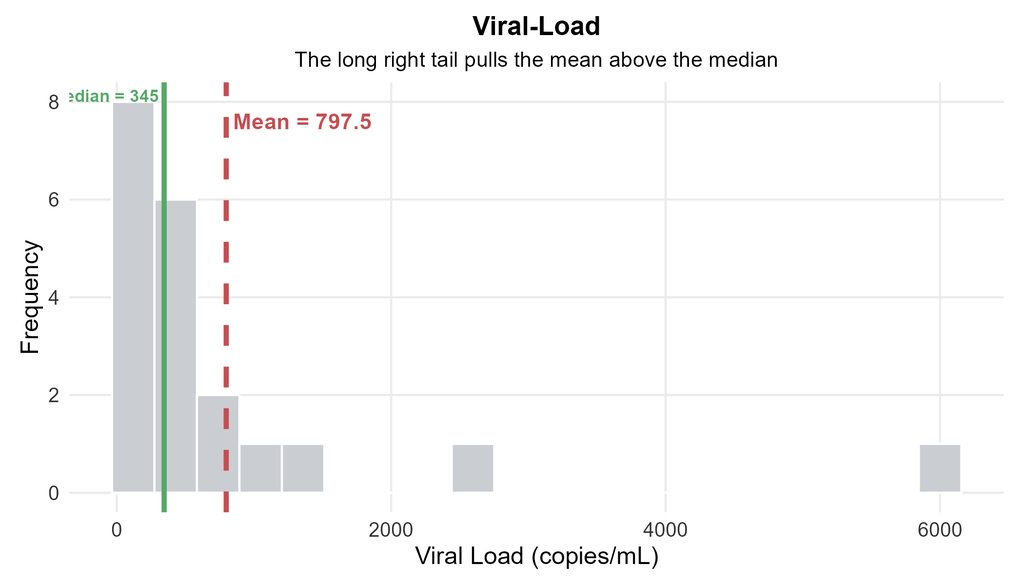

The median of 345 copies/mL provides a more resistant description of the centre of this dataset. The mean of 797.5 copies/mL is much larger because it is pulled toward the long right tail.

The calculation can be checked in R.

```r
# These values are the same illustrative viral-load data shown above.
viral_load <- c(
  120, 140, 160, 180, 200,
  220, 250, 270, 300, 330,
  360, 400, 450, 520, 600,
  750, 900, 1300, 2500, 6000
)

# Compare the two measures of centre.
mean(viral_load)
```

```
## [1] 797.5
```

```r
median(viral_load)
```

```
## [1] 345
```

### 2.3.3 Biological Application: Survival Times

Survival times and similar biological measurements are often right-skewed. Many patients may have outcomes within a relatively compact range, while a smaller number survive much longer and create a long right tail.

This is one reason the **median survival time** is commonly useful when describing the midpoint of an observed survival-time distribution. The median is resistant to a small number of very long survival times.

The mean can still answer a different question because it incorporates every observed patient-day. For planning total resources, staffing or costs, a mean may therefore also be informative.

The important point is not that one measure is always “better.” The mean and median define centre differently, so the scientific question and the shape of the data determine which summary is most useful.

## 2.4 Measuring Spread: Quartiles and the IQR

A measure of centre does not describe how widely the observations vary.

For example, suppose the median body weight in a sample of penguins is **4.5 kg**. That tells us where the middle of the distribution lies, but it does not tell us whether most penguins weigh close to 4.5 kg or whether the observed weights range widely, perhaps from about 2 kg to 8 kg.

Two datasets can therefore have the same median while having very different amounts of spread.

> **Centre and spread belong together.**

> A numerical description of a distribution should usually report a measure of centre together with a measure of variability.

Quartiles describe positions in the ordered data and provide a resistant way to measure spread.

### 2.4.1 Quartiles

The first quartile $Q_1$ is the 25th percentile and the third quartile $Q_3$ is the 75th percentile.

Different statistical software packages use slightly different interpolation rules for quartiles. For hand calculations in this course, the **median-of-halves convention** will be used unless another method is specified.

Under this convention:

1. The observations are sorted from smallest to largest.
2. The overall median is located.
3. For odd $n$, the overall median is excluded from the lower and upper halves.
4. The median of the lower half is $Q_1$.
5. The median of the upper half is $Q_3$.

#### 2.4.1.1 Example 2.5: Quartiles with Odd $n$

**Question**

What are $Q_1$ and $Q_3$ for the 15 Aleppo pine needle lengths?

**Explanation**

The overall median is 9.3 cm. Because the sample size is odd, that value is excluded when the lower and upper halves are formed.

The lower half is

7.2, 7.6, 8.5, 8.5, 8.7, 9.0, 9.0

The upper half is

9.4, 9.4, 10.2, 10.9, 11.3, 12.1, 12.8

**Solution**

The middle value of the lower half is

$$Q_1
=
8.5\text{ cm}$$

The middle value of the upper half is

$$Q_3
=
10.9\text{ cm}$$

R can also summarize the data.

```r
# summary() reports the minimum, Q1, median, mean, Q3 and maximum.
summary(aleppo_needles)
```

```
##    Min. 1st Qu.  Median    Mean 3rd Qu.    Max.
##   7.200   8.600   9.300   9.593  10.550  12.800
```

R uses an interpolation rule for quartiles that can differ slightly from the hand-calculation convention used above. A small difference is therefore not necessarily an error.

#### 2.4.1.2 Example 2.6: Quartiles with Even $n$

**Question**

What are $Q_1$ and $Q_3$ for the 18 Torrey pine needle lengths?

**Explanation**

The median lies between 26.6 and 26.8. The lower half contains the first nine observations and the upper half contains the final nine observations.

The middle observation of the lower half is 23.7 cm. The middle observation of the upper half is 29.7 cm.

**Solution**

$$Q_1
=
23.7\text{ cm}$$

$$Q_3
=
29.7\text{ cm}$$

```r
# summary() gives R's numerical summary for the Torrey pine sample.
summary(torrey_needles)
```

```
##    Min. 1st Qu.  Median    Mean 3rd Qu.    Max.
##   21.20   23.82   26.70   27.00   29.70   33.70
```

#### 2.4.1.3 Software Note: Why Can R’s Quartiles Differ from the Hand Calculation?

There is more than one accepted convention for locating quartiles when the desired percentile falls between observed values. Our hand calculations use the **median-of-halves** rule because it is easy to apply manually.

R’s default calculation uses interpolation between ordered observations. As a result, R reports $Q_1=8.60$ and $Q_3=10.55$ for the Aleppo pine data, rather than the hand-calculated values $8.5$ and $10.9$.

This difference is not a contradiction. It reflects a different quartile convention. In software-based analysis, use one method consistently and report the method when the distinction matters.

### 2.4.2 The Interquartile Range

The **interquartile range**, abbreviated IQR, measures the width of the middle 50% of the ordered data.

$$IQR
=
Q_3-Q_1$$

The IQR is resistant because the most extreme observations in the tails do not directly determine its value.

### 2.4.3 Distribution Shape and Suspected Outliers

An observation can be unusual in a symmetric distribution or in a skewed distribution. **Skewness and outliers are different ideas.**

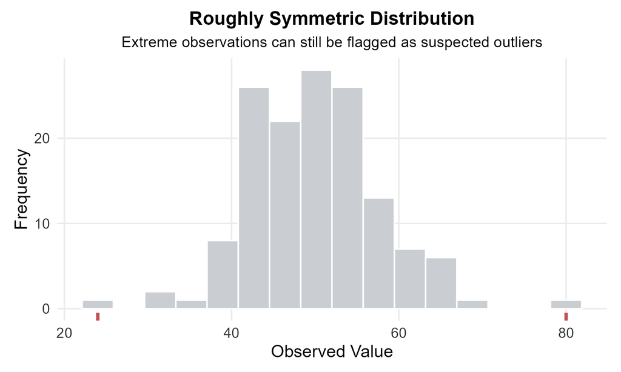

In a roughly symmetric, bell-shaped distribution, most observations may cluster near the centre while one or more values lie far from the main group.

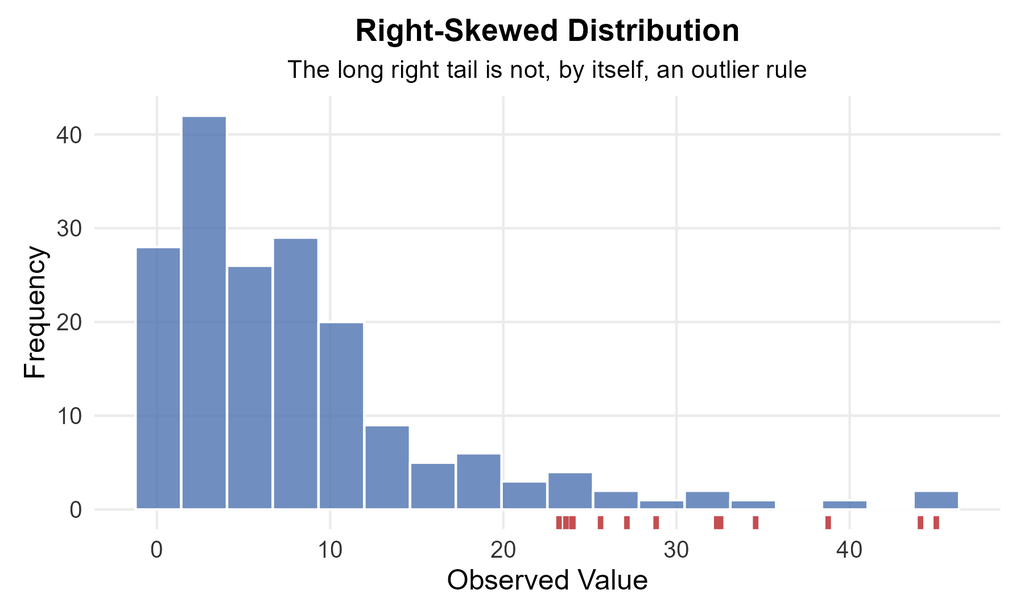

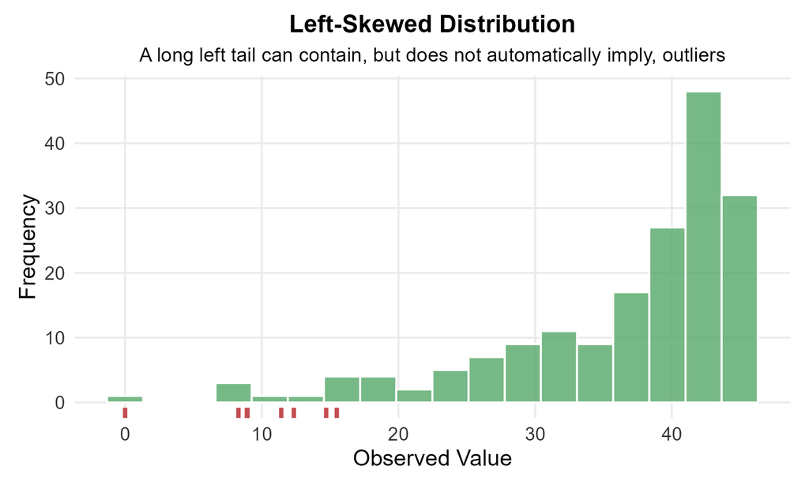

A right-skewed distribution naturally has a long right tail, and a left-skewed distribution naturally has a long left tail. A point is **not** an outlier merely because it lies in a tail. Later in this chapter, the $1.5\times IQR$ rule will provide a numerical rule for flagging observations as **suspected outliers**.

### 2.4.4 Calculating the IQR in R

R calculates the IQR directly with `IQR(x)`.

```r
# IQR() calculates the interquartile range using R's quartile convention.
IQR(aleppo_needles)
```

```
## [1] 1.95
```

```r
IQR(torrey_needles)
```

```
## [1] 5.875
```

For the Aleppo pine sample, R uses its own quartile convention:

$$IQR
=
10.55-8.60
=
1.95\text{ cm}.$$

### 2.4.5 The Five-Number Summary

The five-number summary consists of

$$\text{Minimum}
\quad
Q_1
\quad
\text{Median}
\quad
Q_3
\quad
\text{Maximum}$$

These five values provide a compact description of the location and spread of the ordered data. They do not show every feature of a distribution, so the graph should still be examined.

A modified boxplot uses the quartiles together with the $1.5\times IQR$ rule to display suspected outliers separately.

## 2.5 Boxplots

A **boxplot** provides a compact visual summary of a quantitative distribution. It is especially useful for comparing several groups.

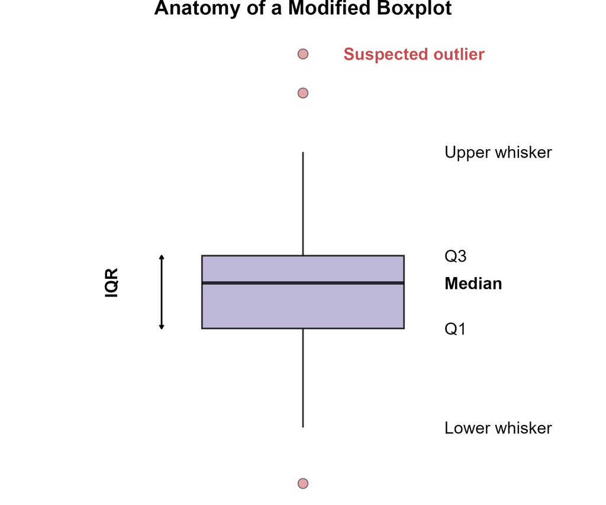

### 2.5.1 Reading a Modified Boxplot

The box extends from $Q_1$ to $Q_3$, so its height or width represents the IQR. The line inside the box marks the median.

The whiskers extend to the most extreme observations that remain within the outlier fences. Observations beyond the fences are shown separately as suspected outliers.

A point marked as a suspected outlier should be investigated rather than automatically deleted.

### 2.5.2 Comparing Groups with Side-by-Side Boxplots

Side-by-side boxplots allow the centres, spreads and unusual observations of several groups to be compared on the same scale.

The figure below uses simulated editing-efficiency values only to illustrate how such a comparison can be read.

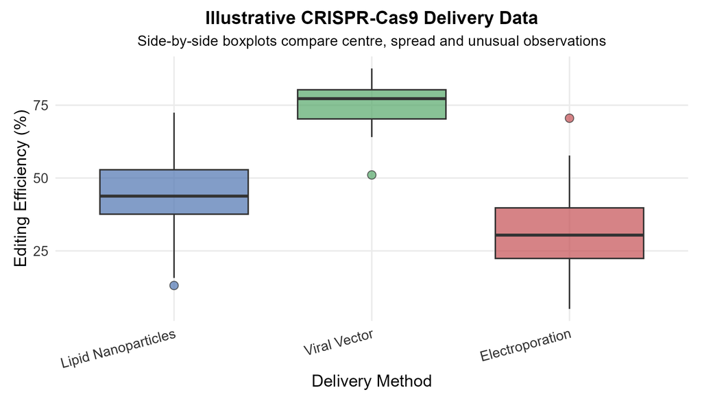

The comparison should focus on several features.

- The medians show differences in centre between the groups.
- The IQRs show differences in the spread of the middle 50%.
- The whiskers and separately plotted points show the behaviour of the tails.
- The amount of overlap helps describe how distinct or similar the group distributions appear.

In this **illustrative simulated dataset**, the viral-vector group is centred at a higher editing efficiency than the other two groups. The electroporation group has a wider middle spread, while isolated points beyond whiskers—when present—should be treated as suspected outliers and investigated rather than automatically removed.

The graph is descriptive. A difference between boxplots alone does not establish that one delivery method causes a better biological outcome.

## 2.6 Identifying Suspected Outliers: The $1.5\times IQR$ Rule

A modified boxplot uses the IQR to define objective boundaries called **fences**.

The lower fence is

$$Q_1-1.5(IQR)$$

The upper fence is

$$Q_3+1.5(IQR)$$

An observation below the lower fence or above the upper fence is flagged as a suspected outlier.

The word **suspected** is important. The rule identifies an unusual numerical value. It does not determine whether the observation is a data-entry error, a measurement problem or a valid biological observation.

#### 2.6.0.1 Example: Applying the Outlier Rule

**Question**

The following needle-length dataset contains an unusually large observation.

7.2, 7.6, 8.5, 8.5, 8.7, 9.0, 9.0, 9.3, 9.4, 9.4, 10.2, 10.9, 11.3, 12.1, 15.8

How can R identify observations outside the $1.5\times IQR$ fences?

**Explanation**

The first quartile, third quartile and IQR are calculated first. The two fences are then constructed. The final logical condition selects values that fall outside those boundaries.

**Solution**

```r
# The vector contains the observed needle lengths.
needle_data <- c(
  7.2, 7.6, 8.5, 8.5, 8.7,
  9.0, 9.0, 9.3, 9.4, 9.4,
  10.2, 10.9, 11.3, 12.1, 15.8
)

# R's default quartile convention is used for this software calculation.
q1 <- quantile(needle_data, 0.25)
q3 <- quantile(needle_data, 0.75)
iqr_value <- IQR(needle_data)

# The lower and upper fences define the usual suspected-outlier region.
lower_fence <- q1 - 1.5 * iqr_value
upper_fence <- q3 + 1.5 * iqr_value

# Display both fences.
c(
  Lower_Fence = lower_fence,
  Upper_Fence = upper_fence
)
```

```
## Lower_Fence.25% Upper_Fence.75%
##           5.675          13.475
```

```r
# Select observations outside either fence.
suspected_outliers <- needle_data[
  needle_data < lower_fence |
  needle_data > upper_fence
]

suspected_outliers
```

```
## [1] 15.8
```

A flagged observation should be investigated scientifically before any decision is made about excluding it.

## 2.7 Measuring Spread: Standard Deviation

The median is naturally paired with the IQR because both are resistant. The mean is commonly paired with the **standard deviation**, denoted by $s$ for a sample.

The standard deviation describes how much the observations vary around the sample mean. It is based on squared deviations from the mean, so large deviations receive substantial weight.

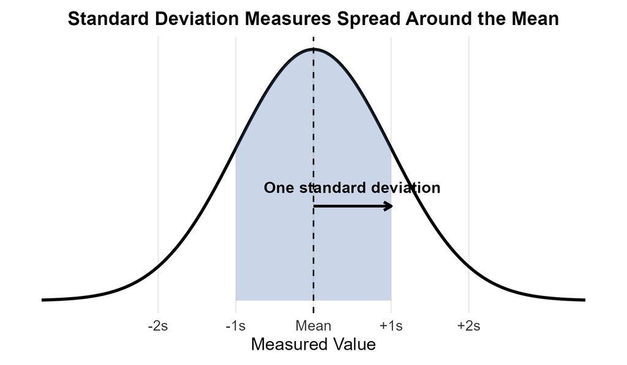

### 2.7.1 Deviations, Variance and Standard Deviation

For observation $x_i$, the deviation from the sample mean is

$$x_i-\bar{x}$$

Positive deviations correspond to observations above the mean. Negative deviations correspond to observations below the mean.

The deviations always sum to zero.

$$\sum_{i=1}^{n}(x_i-\bar{x})
=
0$$

The deviations are squared so that positive and negative differences do not cancel.

The sample variance is

$$s^2
=
\frac{1}{n-1}
\sum_{i=1}^{n}
(x_i-\bar{x})^2$$

The sample standard deviation is the square root of the sample variance.

$$s
=
\sqrt{
\frac{1}{n-1}
\sum_{i=1}^{n}
(x_i-\bar{x})^2
}$$

### 2.7.2 Degrees of Freedom: Why Do We Divide by $n-1$?

The denominator in the sample variance is $n-1$ rather than $n$. This is connected to **degrees of freedom**.

Once the sample mean has been calculated, the deviations

$$x_1-\bar{x},\;
x_2-\bar{x},\;
\ldots,\;
x_n-\bar{x}$$

must add to zero. If the first $n-1$ deviations are known, the final deviation is forced to be whatever value makes the total equal zero. Only $n-1$ deviations can therefore vary independently.

Under the usual independent random-sampling model, dividing the sum of squared deviations by $n-1$ also corrects the downward bias that would result from using $n$. More precisely, this makes the sample **variance** $s^2$ an unbiased estimator of the population variance $\sigma^2$.

The sample standard deviation $s$ itself is not exactly unbiased for the population standard deviation $\sigma$, so the bias-correction statement should be attached to the variance rather than to the standard deviation.

### 2.7.3 Example 2.7: Metabolic Rates

**Question**

The metabolic rates of seven men in a dieting study are measured in Calories per 24 hours.

1792, 1666, 1362, 1614, 1460, 1867, 1439

What are the sample variance and sample standard deviation?

**Explanation**

The first step is the sample mean.

$$\bar{x}
=
\frac{11200}{7}
=
1600\text{ Cal}$$

Each observation is compared with 1600. The deviations and squared deviations are shown below.

| Observation $x_i$ | Deviation $x_i-\bar{x}$ | Squared deviation $(x_i-\bar{x})^2$ |
| --- | --- | --- |
| 1792 | 192 | 36,864 |
| 1666 | 66 | 4,356 |
| 1362 | -238 | 56,644 |
| 1614 | 14 | 196 |
| 1460 | -140 | 19,600 |
| 1867 | 267 | 71,289 |
| 1439 | -161 | 25,921 |
| **Total** | **0** | **214,870** |

The sum of the deviations is zero, which is why the squared deviations are used to measure spread.

**Solution**

The sample variance is

$$s^2
=
\frac{214870}{7-1}
=
35811.67\text{ Cal}^2$$

The sample standard deviation is

$$s
=
\sqrt{35811.67}
\approx
189.24\text{ Cal}$$

The metabolic rates have a mean of 1600 Cal per day and a standard deviation of about 189.24 Cal.

R performs both calculations directly.

```r
# The vector contains the seven observed metabolic rates.
metabolic_rates <- c(
  1792, 1666, 1362, 1614,
  1460, 1867, 1439
)

# var() calculates the sample variance using n - 1.
var(metabolic_rates)
```

```
## [1] 35811.67
```

```r
# sd() calculates the sample standard deviation.
sd(metabolic_rates)
```

```
## [1] 189.2397
```

### 2.7.4 Properties of Standard Deviation

Several properties help with interpretation.

- The value of $s$ measures spread around the sample mean.
- The value of $s$ is zero only when all observations are identical.
- The standard deviation has the same measurement units as the original data.
- The variance has squared units.
- The standard deviation is non-resistant because extreme observations create large squared deviations.

The phrase **average distance from the mean** can be useful as an informal intuition, but the standard deviation is not the ordinary arithmetic average of the absolute distances. Its formula is based on squared deviations.

## 2.8 Choosing the Appropriate Numerical Summary

The graph should guide the choice of numerical summaries.

| Distribution | Centre | Spread | Reason |
| --- | --- | --- | --- |
| Roughly symmetric without strong outliers | Mean | Standard deviation | Both summaries use all observed values |
| Strongly skewed or containing extreme observations | Median | IQR | Both summaries are resistant |

This guideline does not replace scientific judgment. The context of the variable matters. Both sets of summaries can sometimes be reported when a fuller description is useful.

The important principle is that centre and spread should be reported as a pair. A centre without a measure of variability gives an incomplete description of a distribution.

## 2.9 Summary of R Commands

The following functions are the main R commands introduced in this chapter.

| R command | What it does |
| --- | --- |
| `c(1, 2, 3)` | Combines values into a vector |
| `mean(x)` | Calculates the sample mean |
| `median(x)` | Calculates the median |
| `summary(x)` | Reports the minimum, first quartile, median, mean, third quartile and maximum |
| `IQR(x)` | Calculates the interquartile range using R’s quartile convention |
| `var(x)` | Calculates the sample variance $s^2$ |
| `sd(x)` | Calculates the sample standard deviation $s$ |

These commands calculate summaries; they do not decide whether a particular summary is scientifically appropriate. The graph and the context should guide that choice.

## 2.10 Chapter Summary

A clear numerical description of a quantitative distribution usually follows a consistent workflow.

1. **The distribution is plotted first.** Its shape and unusual observations should be examined before numerical summaries are selected.
2. **A measure of centre is chosen.** The mean is sensitive to extreme values, while the median is resistant.
3. **A matching measure of spread is chosen.** The standard deviation is commonly paired with the mean, while the IQR is commonly paired with the median.
4. **Quartiles and the five-number summary describe ordered positions.** They provide the foundation for boxplots.
5. **The $1.5\times IQR$ rule flags suspected outliers.** A flagged observation should be investigated rather than automatically removed.
6. **Side-by-side boxplots compare distributions across groups.** The comparison should consider centre, spread, tails and unusual observations.

A useful final question is: **Do the numerical summaries tell the same story as the graph?** When the graph and the chosen summaries disagree, the graph often reveals the reason.

### 2.10.1 Looking Ahead to Chapter 3

Chapters 1 and 2 focus mainly on describing one variable at a time. Many scientific questions instead involve two quantitative variables measured on the same individuals.

Examples include whether blood pressure tends to change with drug dosage or whether body size is associated with another biological measurement.

Chapter 3 introduces scatterplots and correlation as tools for describing relationships between two quantitative variables.